# Lab 3: MATH 4753

Joshua Wiseman

February 3, 2023

# Tasks

## Task 1

WD

```r
getwd()
```

```
## [1] "/home/joshua/Desktop/MainFolder/OuClasses/Spring 2023/Applied Statistical Methods/FALL224753wise0046/LABS/LAB3"
```

## Task 2

```r
spruce.df = read.csv("SPRUCE.csv")
head(spruce.df)
```

```
##   BHDiameter Height
## 1       18.9   20.0
## 2       16.6   18.8
## 3       15.5   16.8
## 4       15.5   16.9
## 5       19.4   20.2
## 6       13.7   16.3
```

## Task 3

1. Make a scatter plot of the data (y axis will be the Height).

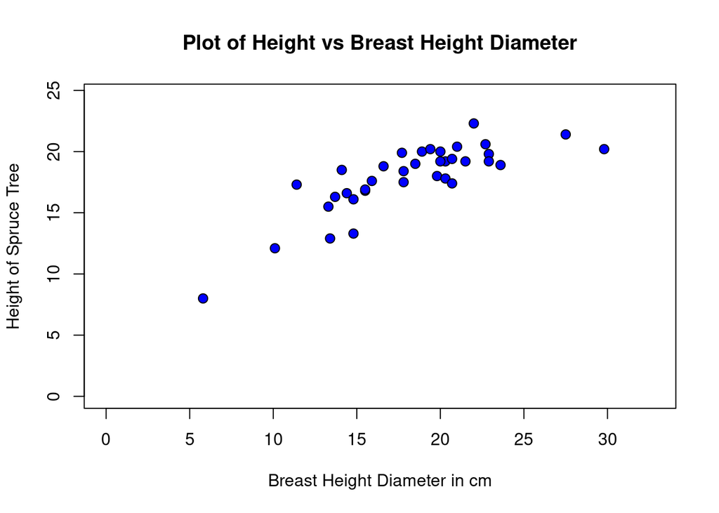

```r
plot(spruce.df$Height~spruce.df$BHDiameter, bg="Blue",pch=21, xlim = c(0, 1.1*max(spruce.df$BHDiameter)), xlab = "Breast Height Diameter in cm", ylim = c(0, 1.1*max(spruce.df$Height)), ylab = "Height of Spruce Tree", cex = 1.2, main = "Plot of Height vs Breast Height Diameter")
```

2. Does there appear to be a straight line relationship? `No, a curve would be more appropriate.`
3. Load the library s20x and make a lowess smoother scatter plot using trendscatter() (try a few values of f, f=0.5,0.6,0.7) record all three plots, use layout().

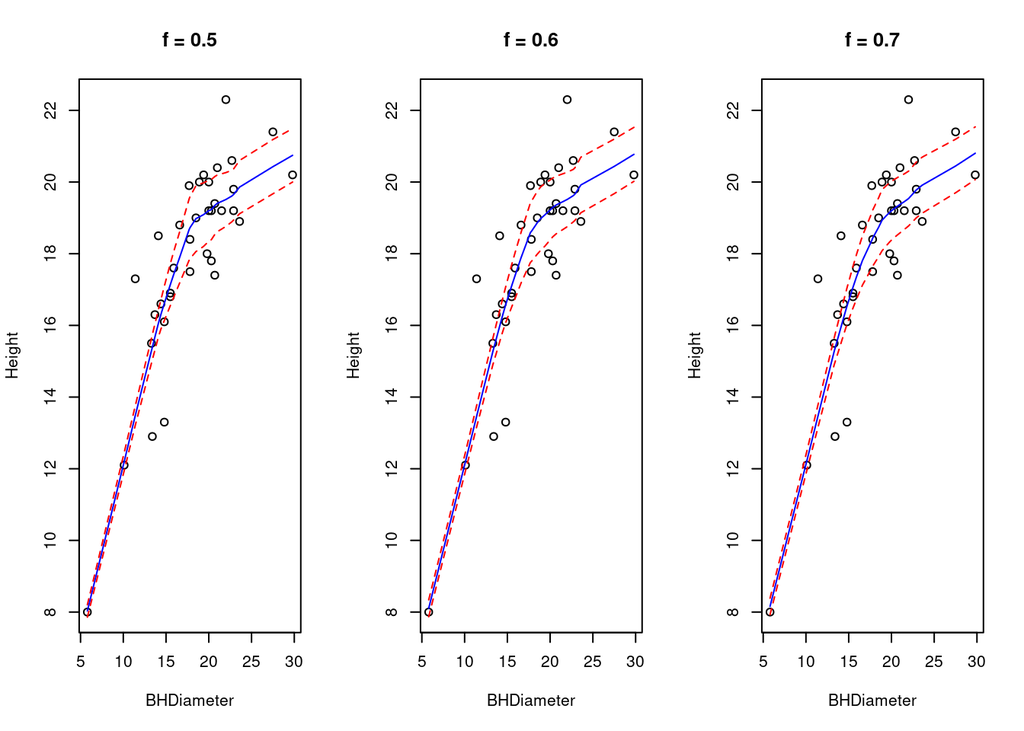

```r
library(s20x)
layout(matrix(1:3,nr=1,nc=3,byrow=TRUE))
trendscatter(Height~BHDiameter,f=0.5, data=spruce.df, main = "f = 0.5")
trendscatter(Height~BHDiameter,f=0.6, data=spruce.df, main = "f = 0.6")
trendscatter(Height~BHDiameter,f=0.7, data=spruce.df, main = "f = 0.7")
```

4. We will assume (this may in fact be a bad assumption) a straight line relationship, use lm and make a linear model object, call it spruce.lm

```r
spruce.lm = with(spruce.df, lm(Height~BHDiameter))
```

5. Make a new scatter plot and add the least squares regression line to the points - abline(spruce.lm) – record the plot.

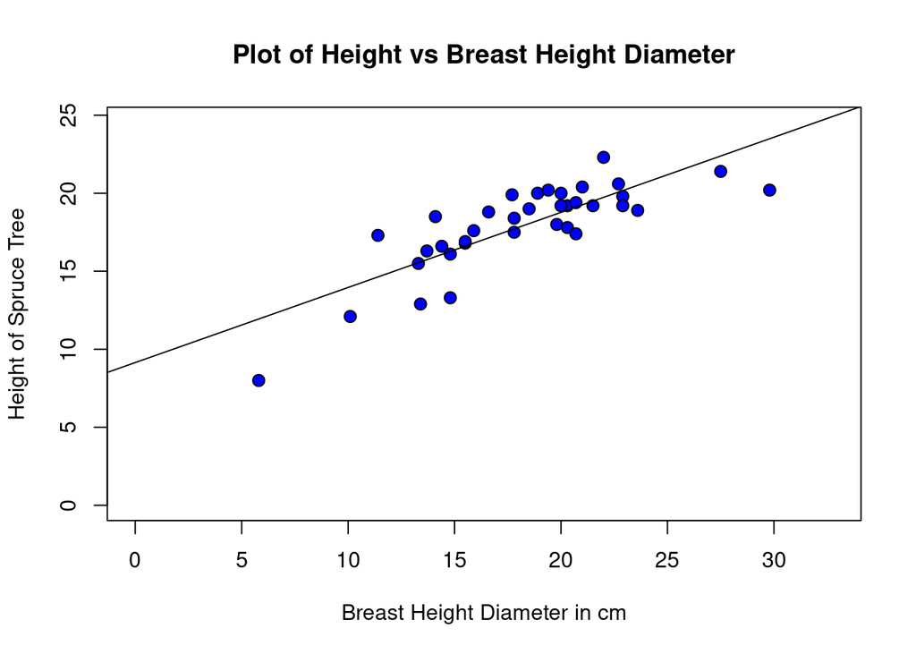

```r
layout(1)
plot(spruce.df$Height~spruce.df$BHDiameter, bg="Blue",pch=21, xlim = c(0, 1.1*max(spruce.df$BHDiameter)), xlab = "Breast Height Diameter in cm", ylim = c(0, 1.1*max(spruce.df$Height)), ylab = "Height of Spruce Tree", cex = 1.2, main = "Plot of Height vs Breast Height Diameter")
abline(spruce.lm)
```

## Task 4

1. Divide the graphical interface into 4 equal areas, use layout.show(4) and record the picture.

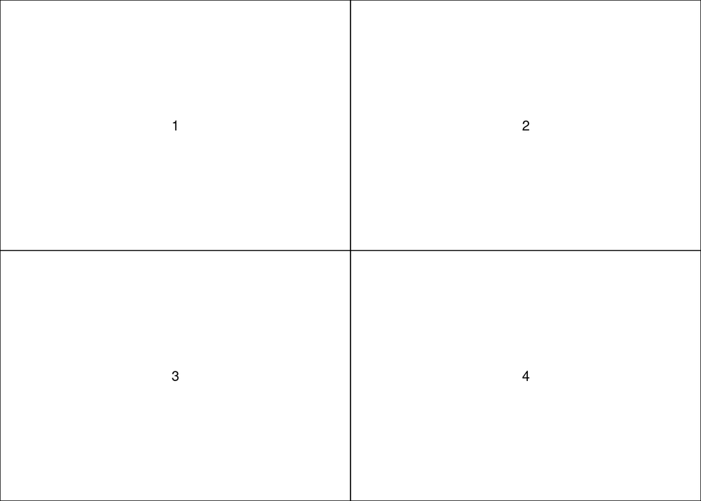

```r
# First Square Plot
layout(matrix(1:4,nr=2,nc=2,byrow=TRUE))
layout.show(4)
```

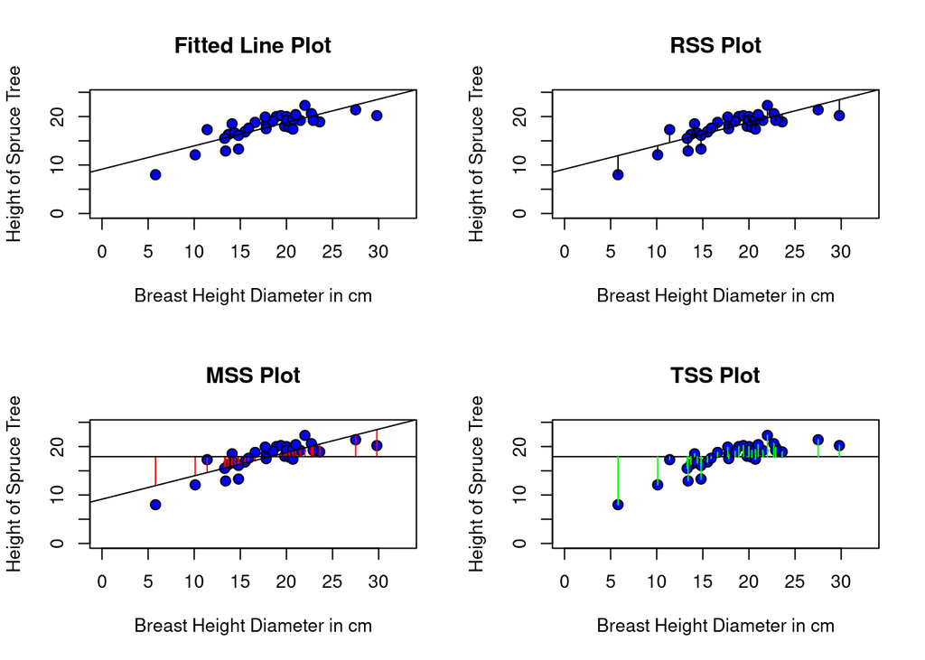

```r
plot(spruce.df$Height~spruce.df$BHDiameter, bg="Blue",pch=21, xlim = c(0, 1.1*max(spruce.df$BHDiameter)), xlab = "Breast Height Diameter in cm", ylim = c(0, 1.1*max(spruce.df$Height)), ylab = "Height of Spruce Tree", cex = 1.2, main = "Fitted Line Plot")
abline(spruce.lm)

# Second Square Plot
plot(spruce.df$Height~spruce.df$BHDiameter, bg="Blue",pch=21, xlim = c(0, 1.1*max(spruce.df$BHDiameter)), xlab = "Breast Height Diameter in cm", ylim = c(0, 1.1*max(spruce.df$Height)), ylab = "Height of Spruce Tree", cex = 1.2, main = "RSS Plot")
yhat = fitted(spruce.lm)
with(spruce.df,{
segments(BHDiameter,Height,BHDiameter,yhat)
})
abline(spruce.lm)

# Third Square Plot
plot(spruce.df$Height~spruce.df$BHDiameter, bg="Blue",pch=21, xlim = c(0, 1.1*max(spruce.df$BHDiameter)), xlab = "Breast Height Diameter in cm", ylim = c(0, 1.1*max(spruce.df$Height)), ylab = "Height of Spruce Tree", cex = 1.2, main = "MSS Plot")
with(spruce.df, segments(BHDiameter,mean(Height),BHDiameter,yhat,col="Red"))
abline(spruce.lm)
with(spruce.df,abline(h=mean(Height)))

# Fourth Square Plot
plot(spruce.df$Height~spruce.df$BHDiameter, bg="Blue",pch=21, xlim = c(0, 1.1*max(spruce.df$BHDiameter)), xlab = "Breast Height Diameter in cm", ylim = c(0, 1.1*max(spruce.df$Height)), ylab = "Height of Spruce Tree", cex = 1.2, main = "TSS Plot")
with(spruce.df,abline(h=mean(Height)))
with(spruce.df, segments(BHDiameter,Height,BHDiameter,mean(Height),col="Green"))
```

2. Calculate TSS, MSS and RSS

```r
RSS = with(spruce.df,sum((Height-yhat)^2))
RSS
```

```
## [1] 95.70281
```

```r
MSS = with(spruce.df,sum((yhat-mean(Height))^2))
MSS
```

```
## [1] 183.2447
```

```r
TSS = with(spruce.df,sum((Height-mean(Height))^2))
TSS
```

```
## [1] 278.9475
```

3. Calculate $MSS/TSS$, and interpret it! `The ratio of how well BHDiameter predicts Height or the calculation of R^2.`

```r
MSS/TSS
```

```
## [1] 0.6569146
```

4. Does TSS = MSS + RSS? `YES`

```r
MSS + RSS
```

```
## [1] 278.9475
```

```r
TSS
```

```
## [1] 278.9475
```

## Task 5

1. Summarize spruce.lm paste it here.

```r
summary(spruce.lm)
```

```
##
## Call:
## lm(formula = Height ~ BHDiameter)
##
## Residuals:
##     Min      1Q  Median      3Q     Max
## -3.9394 -0.9763  0.2829  0.9950  2.6644
##
## Coefficients:
##             Estimate Std. Error t value Pr(>|t|)
## (Intercept)  9.14684    1.12131   8.157 1.63e-09 ***
## BHDiameter   0.48147    0.05967   8.069 2.09e-09 ***
## ---
## Signif. codes:  0 '***' 0.001 '**' 0.01 '*' 0.05 '.' 0.1 ' ' 1
##
## Residual standard error: 1.678 on 34 degrees of freedom
## Multiple R-squared:  0.6569, Adjusted R-squared:  0.6468
## F-statistic:  65.1 on 1 and 34 DF,  p-value: 2.089e-09
```

2. What is the value of the slope? `0.48147`
3. What is the value of the intercept? `9.14684`
4. Write down the equation of the fitted line. `Height = 9.1468 + (0.48147)BHDiameter`
5. Predict the Height of spruce when the Diameter is 15, 18 and 20cm (use predict())

```r
predict(spruce.lm, data.frame(BHDiameter = c(15, 18, 20)))
```

```
##        1        2        3
## 16.36895 17.81338 18.77632
```

## Task 6

1. Use appropriate code using the ggplot2 package to make a plot of Height Vs Diameter with shading lines and legend

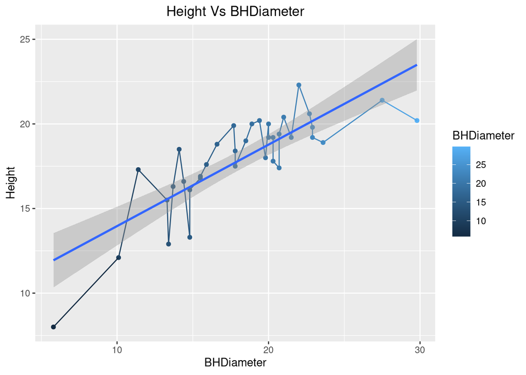

```r
library(ggplot2)
g=ggplot(spruce.df, aes(x=BHDiameter,y=Height, colour=BHDiameter))
g=g+geom_point() + geom_line()+ geom_smooth(method="lm")
g+ggtitle("Height Vs BHDiameter") + theme(plot.title = element_text(hjust = 0.5))
```

## Task 7

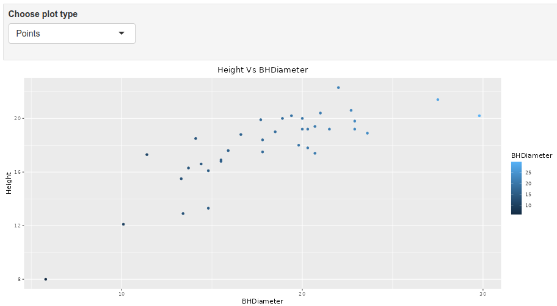

“Points alone”

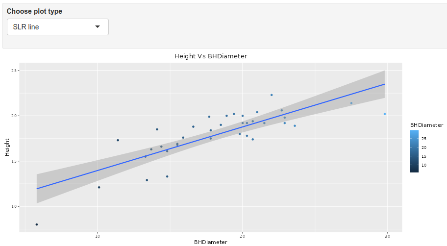

“SLR line”

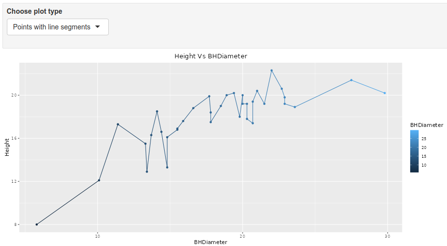

“Points with line segments”